# Tutorial of applying STEAM to evaluate clustering performance using the DLPFC spatial transcriptomic data

06-30-2025

This vignette outlines the steps of applying STEAM on the 10X Visium DLPFC (Dorsolateral Prefrontal Cortex) data. Four different classification models are implemented in STEAM to evaluate clustering results, including Random Forest, Support Vector Machines, XGBoost, and Multinomial Logistic Regression. Here, cell-type classification is performed by incorporating spatial neighborhood analysis and Random Forest model with cross validation.

Before using STEAM, we recommend preprocessing your spatial transcriptomics data using the **Seurat** framework, as it provides a robust set of tools for spatial data normalization, scaling, and visualization. The Satija Lab offers detailed vignettes to guide you through spatial data preprocessing: - [Seurat Spatial Vignette (Part 1)](https://satijalab.org/seurat/articles/spatial_vignette.html) - [Seurat Spatial Vignette (Part 2 - Seurat v5)](https://satijalab.org/seurat/articles/spatial_v5.html) - [Visium HD Analysis Vignette](https://satijalab.org/seurat/articles/spatial_hd.html)

To run STEAM, you need the following components: - A normalized gene expression matrix - An X,Y spatial coordinates matrix - A vector of ground truth or predicted labels

You can input this data into STEAM in two ways:

**Option 1: Manual Input**  
If you have already prepared each component individually:

```r
STEAM.obj <- LoadSTEAM(
  count_exp = Seurat.obj@assays$SCT$scale.data,
  spatial   = Seurat.obj@images$slice1@coordinates,
  labels    = Seurat.obj$Labs,
  pca = Seurat.obj$pca,
  umap = NULL,
  clusters = NULL,
  Seurat.obj = NULL,
  label.column = NULL,
  assay = "SCT"
)
```

**Option 2: Input a Seurat Object Directly**  
If your data is stored in a Seurat object (with SCT normalization, spatial coordinates, and labels already assigned), you can input it directly:

```r
STEAM.obj <- LoadSTEAM(
  count_exp  = NULL,
  spatial    = NULL,
  labels     = NULL,
  Seurat.obj = Seurat.obj
)
```

Note: When using a Seurat object as input, STEAM expects:

```r
Normalized expression matrix: Seurat.obj@assays$SCT$scale.data
Spatial coordinates: Seurat.obj@images$slice1@coordinates or in Seurat::GetTissueCoordinates(Seurat.obj)
Labels: SeuratObject@meta.data$cell_type, SeuratObject@meta.data$seurat_clusters, or SeuratObject@meta.data$YourLabelsName (if you have custom labels added)
```

# Load libraries

```r
library(STEAM)
library(Seurat)
```

# Load data

DLPFC.RDS is sample 151669 from the DLPFC dataset from Visium by 10X Genomics. This data is already preprocessed and includes a `SCTransform` scaled data matrix by `Seurat`, spatial coordinates, and pre-identified cluster labels

```r
data(DLPFC)
```

# Create the STEAM object

- `count_exp`: The scaled gene expression matrix extracted earlier (`matrix`).
- `spatial`: The spatial coordinates of the cells (`coordinates`), providing spatial context for the data.
- `labels`: The cell type or clusters annotation labels pre-obtained by any clustering methods, which will be served as ground truth or reference for evaluation.
- `Seurat.obj`: Set to NULL, indicating that no additional Seurat object is being passed for this analysis.

```r
# Create a STEAM object using the LoadSTEAM function.
STEAM.obj <- LoadSTEAM(count_exp = DLPFC$matrix, spatial = DLPFC$coordinates, labels = DLPFC$labels, Seurat.obj = NULL)
```

# Run STEAM on the STEAM object using specified parameters

- `STEAM.obj`: The STEAM object created using the LoadSTEAM function.
- `train.ratio`: The proportion of data to use for training.
- `n.size`: Neighborhood size used for averaging spatial data.
- `seed`: Seed for random number generation to ensure reproducibility of results.
- `cv.folds`: Number of folds for cross-validation .
- `cv.repeats`: Number of repetitions for cross-validation.
- `trainval.ratio`: Ratio for splitting the training set into training and validation subsets.
- `model`: The machine learning model to use for classification.
  - `rf` = RandomForest
  - `svm` = Support Vector Machines,
  - `xgb` = XGBoost
  - `multinom` = Multinomial Logistic Regression
- `n.tree`: Number of trees to use for the Random Forest model.
- `kernel`: The kernel type for SVM.
- `MaxNWeights`: The maximum number of weights allowed in the neural network of the `multinom` model.
- `train.folder.name`: Name of the folder where training outputs will be stored (‘train.out’).
- `allowParallel`: Whether to allow parallel computing for faster execution. Set to FALSE to run sequentially.

```r
# Run the STEAM analysis.

STEAM.obj <- RunSTEAM(
  STEAM.obj,
  train.ratio = 0.8,
  n.size = 5,
  seed = 123,
  cv.folds = 10,
  cv.repeats = 3,
  trainval.ratio = 0.8,
  model = "rf",
  n.tree = 100,
  kernel = 'linear',
  train.folder.name = 'train.out',
  allowParallel = TRUE
)
```

```
## Finished Data Splitting
```

```
## Finished neighborhood averaging
```

```
## Finished RandomForest model building with cross-validation
```

```
## Finished Model training
```

```
## Finished Evaluation
```

# Custom Model Training Examples

```r
knitr::opts_chunk$set(eval = FALSE, include = TRUE)

# Random Forest with custom tuning grid
rf_grid <- expand.grid(mtry = c(100, 200, 300))

STEAM.obj <- RunSTEAM(
  STEAM.obj,
  train.ratio = 0.8,
  n.size = 5,
  seed = 123,
  cv.folds = 5,
  cv.repeats = 1,
  trainval.ratio = 0.8,
  model = "rf",
  n.tree = 300,
  train.folder.name = "./model_rf",
  allowParallel = TRUE,
  tune.grid = rf_grid
)

# XGBoost with custom tuning grid
xgb_grid <- expand.grid(
  nrounds = c(100, 300),
  max_depth = c(3, 5),
  eta = c(0.05, 0.1),
  gamma = 0,
  colsample_bytree = 0.8,
  min_child_weight = 1,
  subsample = 0.8
)

STEAM.obj <- RunSTEAM(
  STEAM.obj,
  train.ratio = 0.8,
  n.size = 5,
  seed = 123,
  cv.folds = 5,
  cv.repeats = 1,
  trainval.ratio = 0.8,
  model = "xgb",
  train.folder.name = "./model_xgb",
  allowParallel = TRUE,
  tune.grid = xgb_grid
)

# SVM linear with custom tuning grid
svm_grid <- expand.grid(
  C = c(0.05, 0.1, 0.5, 1),
  sigma = c(0.001, 0.01, 0.05)
)

STEAM.obj <- RunSTEAM(
  STEAM.obj,
  train.ratio = 0.8,
  n.size = 5,
  seed = 123,
  cv.folds = 5,
  cv.repeats = 1,
  trainval.ratio = 0.8,
  model = "svm",
  kernel = "linear",
  train.folder.name = "./model_svm",
  allowParallel = TRUE,
  tune.grid = svm_grid
)


# Multinomial Logistic Regression with custom tuning grid
multinom_grid <- expand.grid(decay = c(1, 5, 10, 15))

STEAM.obj <- RunSTEAM(
  STEAM.obj,
  train.ratio = 0.8,
  n.size = 5,
  seed = 123,
  cv.folds = 5,
  cv.repeats = 1,
  trainval.ratio = 0.8,
  model = "multinom",
  train.folder.name = "./model_multinom",
  allowParallel = TRUE,
  maxnweights = 6000,
  tune.grid = multinom_grid
)
```

# View the Performance Metrics from STEAM

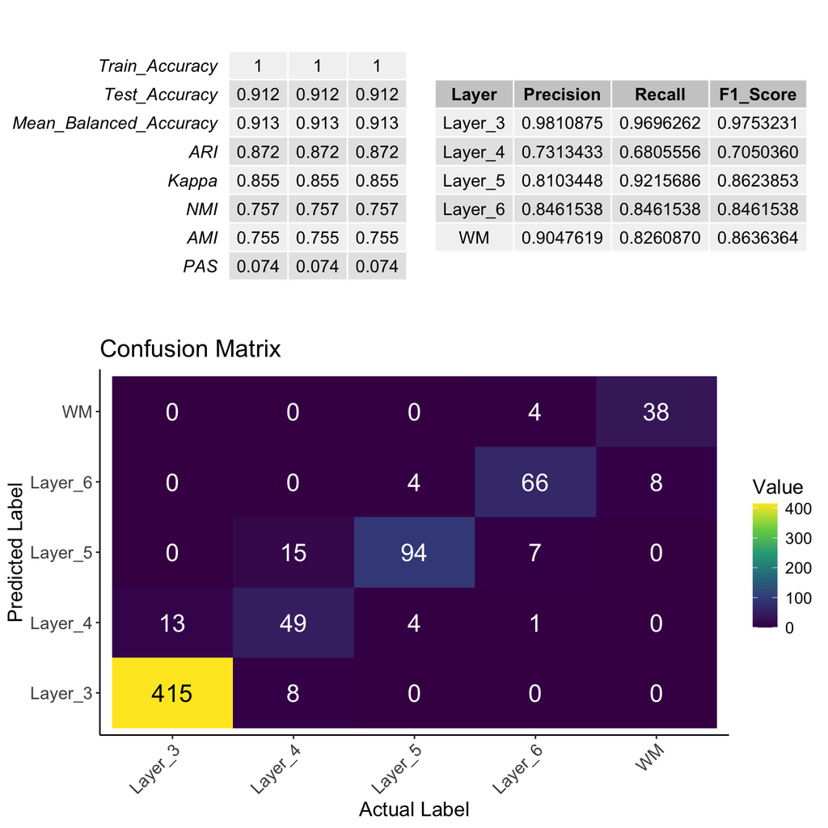

```r
# Evaluation metrics by generating Kappa, F1-score, Accuracy, etc.
ViewMetrics(STEAM.obj)
```

# View the Feature Importance

feature_importance is calculated depending on the type of model used in STEAM.obj during training. A brief overview of how feature importance for each model is calculated:

- `rf`: using varImp() from the `caret` package, the importance scores are extracted and feature importance is calculated as the mean decrease in Gini.
- `xgb`: this also uses varImp() from the `caret` package and computes importance using Gain, which represents the average improvement in the loss function when a feature is used in a split.
- `svm`: the final model is extracted and computes the feature importance using the absolute magnitude of the weight for each feature. Feature weights are calculated from the dot product of SVM coefficients and the support vector matrix.
- `multinom`: the coefficient matrix is extracted, containing the feature coefficients for each class. The feature importance is calculated as the sum of absolute coefficient values across all classes. The intercept term is omitted.

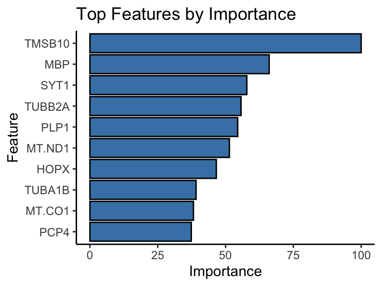

```
##    TMSB10       MBP      SYT1    TUBB2A      PLP1    MT.ND1      HOPX    TUBA1B
## 100.00000  66.08179  57.84057  55.70248  54.48244  51.41562  46.60394  39.13409
##    MT.CO1      PCP4
##  38.16815  37.37097
```

```r
# View feature importance
feature_importance(STEAM.obj, top_n = 10, title = "Top Features by Importance")
```

# View Gene Expression Distribution across Clusters

The feature_expression function extracts the expression values for the user-specified feature across the different layers and plots how the expression varies across layers.

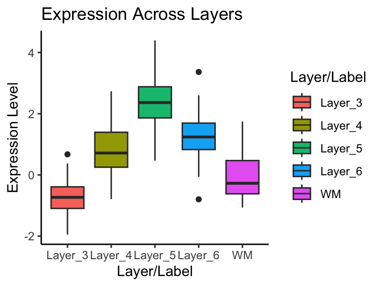

```r
# Show the gene expression per layer
feature_expression(STEAM.obj, feature_name = "TMSB10", title = "Expression Across Layers")
```

# View the Misclassifications

The plot_misclassified_cells function extracts the spatial coordinates and labels from the STEAM.obj and compares the true labels to the model’s predictions in order to identify the misclassified cells. Misclassifications are shown as black dots on the plot.

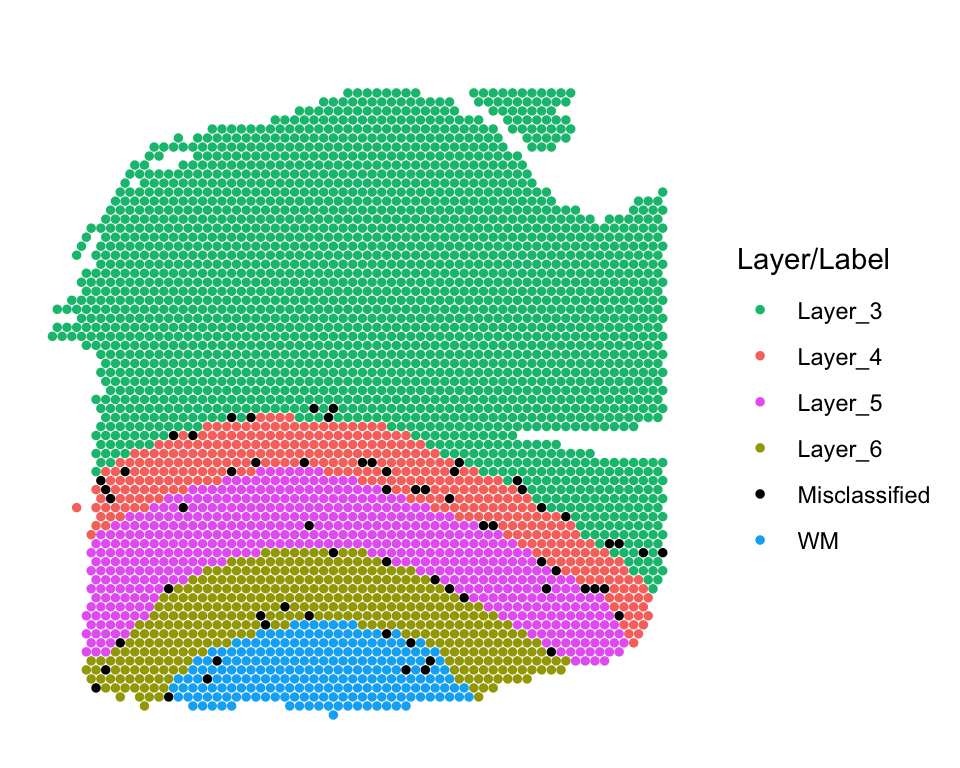

```r
# Plot misclassified cells
plot_misclassified_cells(STEAM.obj)
```